# Deregulated Electricity Markets in US States

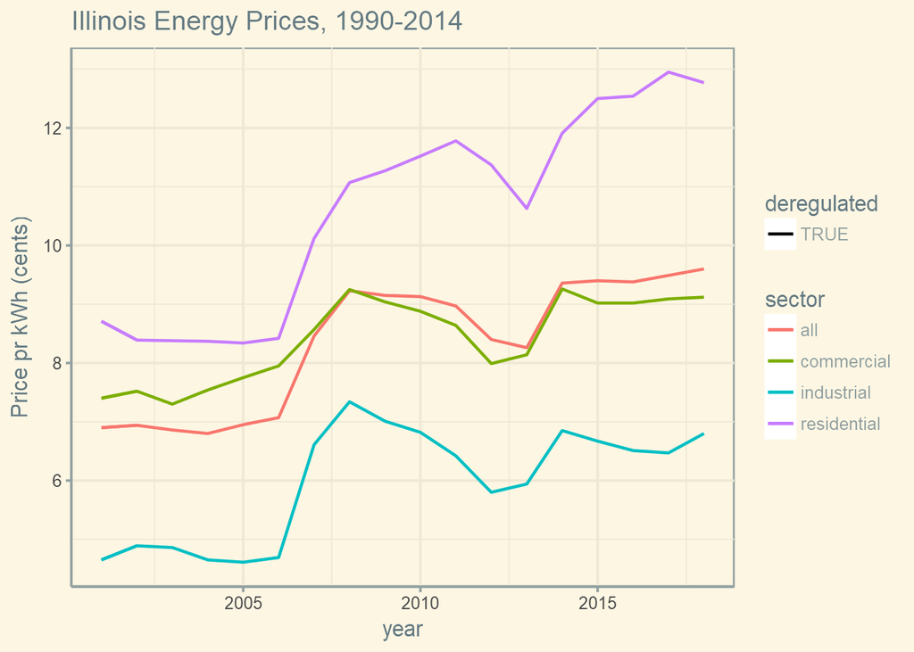

It looks like prices stayed flat for the first four years of deregulation then jumped in 2006 before dropping back down. This is interesting but how do Illinois’ prices compare to other states around them? Let’s look at the states that border Illinois to compare how prices changed across this time period.

Illinois borders Wisconsin, Iowa, Indiana, Missouri, and Kentucky. According to the EIA info, none of those states have had any electricity market restructuring, so it will be an interesting comparison.

For the plot, I will look only at the `Total` sector.

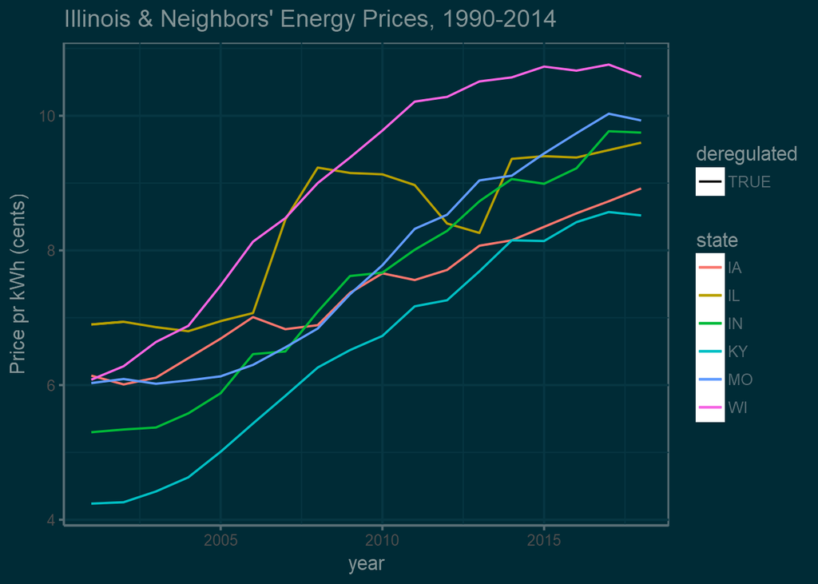

Deregulation is most common in the Northeast region of the US, where eight of nine states have deregulated their electricity markets since the 1990s. In such a geographically tight market, I would expect to see prices really come together in these states.

Of course there are a hundred other factors affecting why energy prices change differently state by state other than the structuring of the markets and I can’t say whether deregulation has benefitted or harmed consumers in any of these states. However, we do have a certain trend in the states that deregulated and stayed that way.

Next post, I will compare the price shifting in some deregulated states to the prices of primary energy sources.